# Pond Inlet Cleaning

2024-10-10

# To Do

Make sure all of the timestamps are loaded Look at roll apply command

# Loading DF’s

Clear Console and add packages

# Load

```r
rm(list = ls())
Sys.setenv(TZ = "UTC")
knitr::opts_chunk$set(error = TRUE)

library(data.table)
library(ggplot2)
library(cowplot)
library(openair)
library(plotrix)
library(signal)
library(svMisc)
library(zoo)
library(stringr)
library(plyr)
library(dplyr)
# Define file names
file_names = list(
  main_file = "PondMet_AllBiomet.dat",
  file1 = "PondMet_AllBiomet_until2024-09-09-full.dat",
  file2 = "PondMet_AllBiomet_until20230620.dat",
  file3 = "PondMet_AllBiomet_until20240910.dat"
)

# Define columns to exclude
exclude_cols = c(36:38)

# Define NA strings
na_strings <- c("-9999", "NA", "NaN", "NAN", "-7999")

# Define column renaming map
oldtempnames = c("ThermocoupleT_Avg(1)", "ThermocoupleT_Avg(2)", "ThermocoupleT_Avg(3)", "ThermocoupleT_Avg(4)",
                 "ThermocoupleT_Avg(5)", "ThermocoupleT_Avg(6)", "ThermocoupleT_Avg(7)", "ThermocoupleT_Avg(8)",
                 "ThermocoupleT_Avg(9)", "SWC_12_36_2_1_1", "SWC_12_36_2_2_1")
newtempnames = c("TS_2_38_2_1_1", "TS_2_38_2_2_1", "TS_2_38_2_3_1", "TS_2_38_2_4_1", "TS_2_38_2_5_1",
                 "TS_2_38_2_6_1", "TS_2_38_2_7_1", "TS_2_38_2_8_1", "TS_2_38_2_9_1", "SWC_12_36_1_2_1",
                 "SWC_12_36_1_3_1")

# Base path for files
base_path = "C:/Users/klynoe/Documents/pond_inlet/data_downloads/met_202411"  # Update this as needed

# Output path for the merged CSV
output_path = file.path("C:/Users/klynoe/Documents/pond_inlet/R_outputs/pond_inlet_met_merged.csv")

# Threshold timestamp for filtering
timestamp_cutoff <- as.POSIXct("2024-07-26 14:00", format = "%Y-%m-%d %H:%M", tz = "UTC")

#timestamp_cutoff <- as.POSIXct("2024-10-30 14:00", format = "%Y-%m-%d %H:%M", tz = "UTC")

# Function to load and preprocess data
load_data <- function(file_name, exclude_cols = NULL, skip = 4) {
  header <- fread(file.path(base_path, file_name), skip = 1, nrows = 0, na.strings = na_strings)
  data <- fread(file.path(base_path, file_name), skip = skip, header = FALSE, na.strings = na_strings)

  setnames(data, names(header))
  return(data)
}

# Load and filter all datasets
df_main <- load_data(file_names$main_file)
dat1 <- load_data(file_names$file1, exclude_cols = exclude_cols)
dat1 <- dat1[as.POSIXct(TIMESTAMP, format = "%Y-%m-%d %H:%M:%S", tz = "UTC") > timestamp_cutoff]

dat2 <- load_data(file_names$file2, exclude_cols = exclude_cols)
dat2 <- dat2[as.POSIXct(TIMESTAMP, format = "%Y-%m-%d %H:%M:%S", tz = "UTC") > timestamp_cutoff]

dat3 <- load_data(file_names$file3, exclude_cols = exclude_cols)
dat3 <- dat3[as.POSIXct(TIMESTAMP, format = "%Y-%m-%d %H:%M:%S", tz = "UTC") > timestamp_cutoff]

# Step 1: Merge all datasets, combining on TIMESTAMP
df_combined <- rbindlist(list(df_main, dat1, dat2, dat3), use.names = TRUE, fill = TRUE)
df_combined <- df_combined[!duplicated(df_combined$TIMESTAMP)] # Remove duplicates

# Step 2: Replace invalid values (-9999, -7999) with NA for consistency
for (col in names(df_combined)) {
  df_combined[[col]] <- fifelse(df_combined[[col]] %in% na_strings, NA, df_combined[[col]])
}


# Step 1: Merge old column data into new columns
for (i in seq_along(oldtempnames)) {

  old_col <- oldtempnames[i]
  new_col <- newtempnames[i]

  # Check if both columns exist in df_combined
  if (old_col %in% names(df_combined) && new_col %in% names(df_combined)) {

    # Merge: Replace NA in new_col with values from old_col if new_col is NA
    df_combined[[new_col]] <- if_else(
      is.na(df_combined[[new_col]]),    # If new_col has NA
      df_combined[[old_col]],           # Replace with values from old_col
      df_combined[[new_col]]            # Otherwise, keep the value in new_col
    )
  } else {
    warning(paste("Column", old_col, "or", new_col, "not found in df_combined"))
    # Print the column names to help debug
    print("Current column names in df_combined:")
    print(names(df_combined))
  }
}

# Step 2: After merging, remove old columns
df_combined[, (oldtempnames) := NULL]
df_combined[, c(2,36:38) := NULL]


# Step 4: Save the cleaned combined data to CSV
df_combined$TIMESTAMP <- as.character(df_combined$TIMESTAMP)  # Convert TIMESTAMP to character for saving
fwrite(df_combined, file = output_path, quote = FALSE)
# Convert TIMESTAMP to POSIXct for time series operations
df_combined$TIMESTAMP <- as.POSIXct(df_combined$TIMESTAMP, format = "%Y-%m-%d %H:%M:%S", tz = "UTC")

# Create a complete sequence of timestamps at 30-minute intervals
tsdf <- data.frame(TIMESTAMP = seq(
  from = min(df_combined$TIMESTAMP, na.rm = TRUE),
  to = max(df_combined$TIMESTAMP, na.rm = TRUE),
  by = "30 min"
))

# Replace specific missing value indicators with NA
df_combined[df_combined == -9999] <- NA
df_combined[df_combined == -7999] <- NA

df= df_combined

summary(df)
```

```
##    TIMESTAMP                       TA_2_1_1_1_1    RH_19_3_1_1_1
##  Min.   :2024-07-26 16:00:00.00   Min.   :-79.42   Min.   : 0.362
##  1st Qu.:2024-08-29 01:07:30.00   1st Qu.:-79.37   1st Qu.: 0.411
##  Median :2024-09-30 02:15:00.00   Median :-79.34   Median : 0.465
##  Mean   :2024-09-29 13:59:50.63   Mean   :-78.05   Mean   : 1.702
##  3rd Qu.:2024-10-31 09:52:30.00   3rd Qu.:-79.31   3rd Qu.: 0.527
##  Max.   :2024-12-01 11:00:00.00   Max.   :  9.52   Max.   :97.500
##  NA's   :126                      NA's   :1
##  WS_16_33_1_1_1   MWS_16_34_1_1_1  WD_20_35_1_1_1    PA_4_2_1_1_1
##  Min.   : 0.000   Min.   : 0.000   Min.   :  0.05   Min.   :  1.966
##  1st Qu.: 1.265   1st Qu.: 2.038   1st Qu.:127.38   1st Qu.: 99.466
##  Median : 2.134   Median : 2.993   Median :169.40   Median :100.051
##  Mean   : 2.438   Mean   : 3.346   Mean   :176.45   Mean   :100.036
##  3rd Qu.: 3.339   3rd Qu.: 4.326   3rd Qu.:237.82   3rd Qu.:100.759
##  Max.   :12.610   Max.   :14.240   Max.   :354.50   Max.   :102.785
##
##  P_RAIN_8_19_1_1_1 SHF_6_37_1_1_1     SHF_6_37_2_1_1    SD_10_99_1_1_1
##  Min.   :0.00000   Min.   :-23.8900   Min.   :-10.680   Min.   : 0.285
##  1st Qu.:0.00000   1st Qu.: -6.8320   1st Qu.: -2.725   1st Qu.: 0.319
##  Median :0.00000   Median : -0.2660   Median : -0.747   Median : 0.358
##  Mean   :0.03119   Mean   : -0.4511   Mean   :  2.768   Mean   :33.940
##  3rd Qu.:0.00000   3rd Qu.:  5.0000   3rd Qu.:  5.985   3rd Qu.:98.300
##  Max.   :3.10000   Max.   : 35.0200   Max.   : 39.700   Max.   :98.600
##                                                         NA's   :1
##  PPFD_7_21_1_1_1    PPFDR_7_23_1_1_1   SWIN_6_10_1_1_1    SWOUT_6_11_1_1_1
##  Min.   :   0.000   Min.   :  0.0000   Min.   : -5.7880   Min.   : -3.4670
##  1st Qu.:   0.000   1st Qu.:  0.0000   1st Qu.: -1.0092   1st Qu.:  0.1210
##  Median :   1.819   Median :  0.3795   Median :  0.2615   Median :  0.7655
##  Mean   :  99.889   Mean   : 13.0114   Mean   : 46.5542   Mean   :  8.8618
##  3rd Qu.:  91.725   3rd Qu.: 13.1025   3rd Qu.: 41.1625   3rd Qu.:  9.3400
##  Max.   :1265.000   Max.   :272.6000   Max.   :615.5000   Max.   :123.1000
##
##  LWIN_6_14_1_1_1 LWOUT_6_15_1_1_1 ALB_6_26_1_1_1       RN_6_5_1_1_1
##  Min.   :152.2   Min.   :184.8    Min.   :-43.53000   Min.   :-85.400
##  1st Qu.:255.0   1st Qu.:280.9    1st Qu.: -0.18000   1st Qu.:-19.052
##  Median :284.9   Median :315.0    Median :  0.12300   Median : -2.823
##  Mean   :282.3   Mean   :306.1    Mean   :  0.09654   Mean   : 13.828
##  3rd Qu.:316.9   3rd Qu.:337.0    3rd Qu.:  0.20300   3rd Qu.: 15.398
##  Max.   :368.4   Max.   :410.1    Max.   : 23.12000   Max.   :420.700
##
```

[output cut: 17 more lines]

```
##  Min.   :-3.4450   Min.   :-2.296   Min.   :-1.8370   Min.   :-1.4010
##  1st Qu.:-1.2803   1st Qu.:-0.386   1st Qu.:-0.1610   1st Qu.:-0.5923
##  Median : 0.2185   Median : 0.287   Median : 0.3155   Median :-0.0460
##  Mean   : 1.2400   Mean   : 1.007   Mean   : 0.8083   Mean   : 0.3243
##  3rd Qu.: 3.5750   3rd Qu.: 2.579   3rd Qu.: 1.8353   3rd Qu.: 1.1253
##  Max.   : 9.7600   Max.   : 5.319   Max.   : 3.6140   Max.   : 2.3630
##
##  TS_2_38_2_7_1     TS_2_38_2_8_1     TS_2_38_2_9_1
##  Min.   :-0.8530   Min.   :-0.6370   Min.   :-0.8430
##  1st Qu.:-0.3120   1st Qu.:-0.2020   1st Qu.:-0.5903
##  Median :-0.1500   Median : 0.0160   Median :-0.4555
##  Mean   : 0.2482   Mean   : 0.1822   Mean   :-0.3772
##  3rd Qu.: 0.7815   3rd Qu.: 0.5920   3rd Qu.:-0.1200
##  Max.   : 1.5850   Max.   : 1.0600   Max.   : 0.1540
##  NA's   :117
```

use for if you want to only look/clean a particular timeperiod

```r
#timestamp_cutoff_start <- as.POSIXct("2024-10-30 14:00", format = "%Y-%m-%d %H:%M", tz = "UTC")
#timestamp_cutoff_end <- as.POSIXct("2024-11-01 14:00", format = "%Y-%m-%d %H:%M", tz = "UTC")

#timestamp_cutoff = as.POSIXct("2024-10-30 14:00", format = "%Y-%m-%d %H:%M", tz = "UTC")

#df = df %>%
  #dplyr::filter(TIMESTAMP >= timestamp_cutoff)
```

Creates a variable to input a date range for the plots in the biomet section of cleaning code. Used to easily change date range for different data sets.

```r
biomet_dates <- c('2024-07-25', '2024-12-01')
#biomet_dates <- c('2024-10-30', '2024-12-01')
```

# Air T

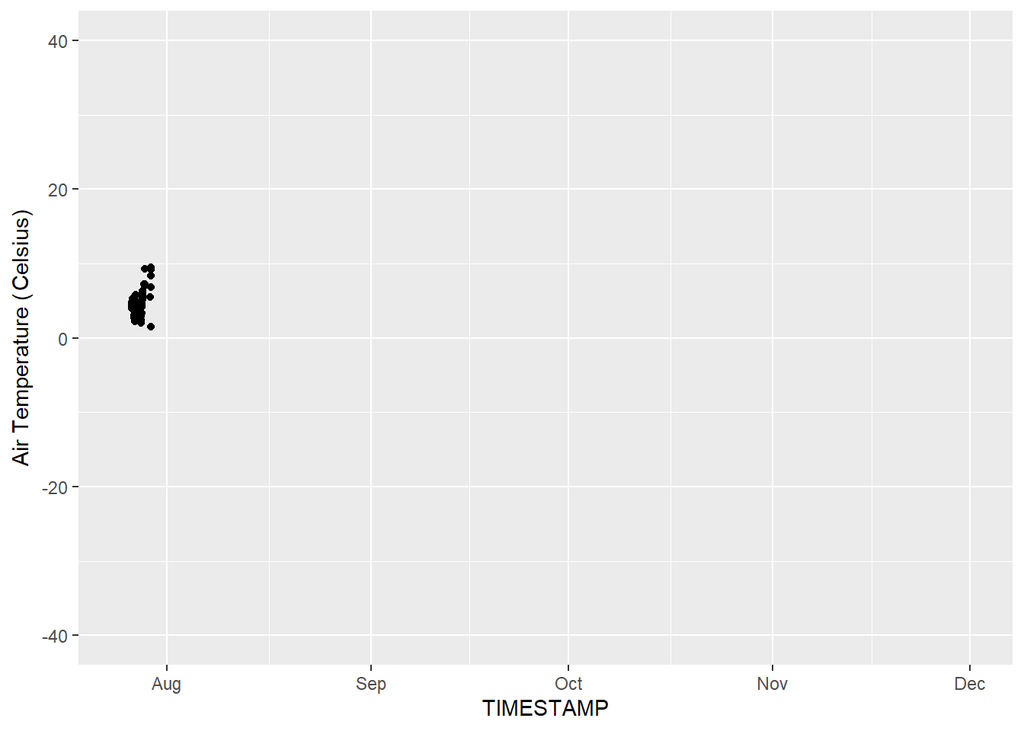

```r
ggplot(data = df)+
  geom_point(aes(TIMESTAMP,TA_2_1_1_1_1),col='black')+
  scale_y_continuous(limits = c(-40,40),
                     expression('Air Temperature ('*Celsius*')'))+
  scale_x_datetime(limits = as.POSIXct(biomet_dates))
```

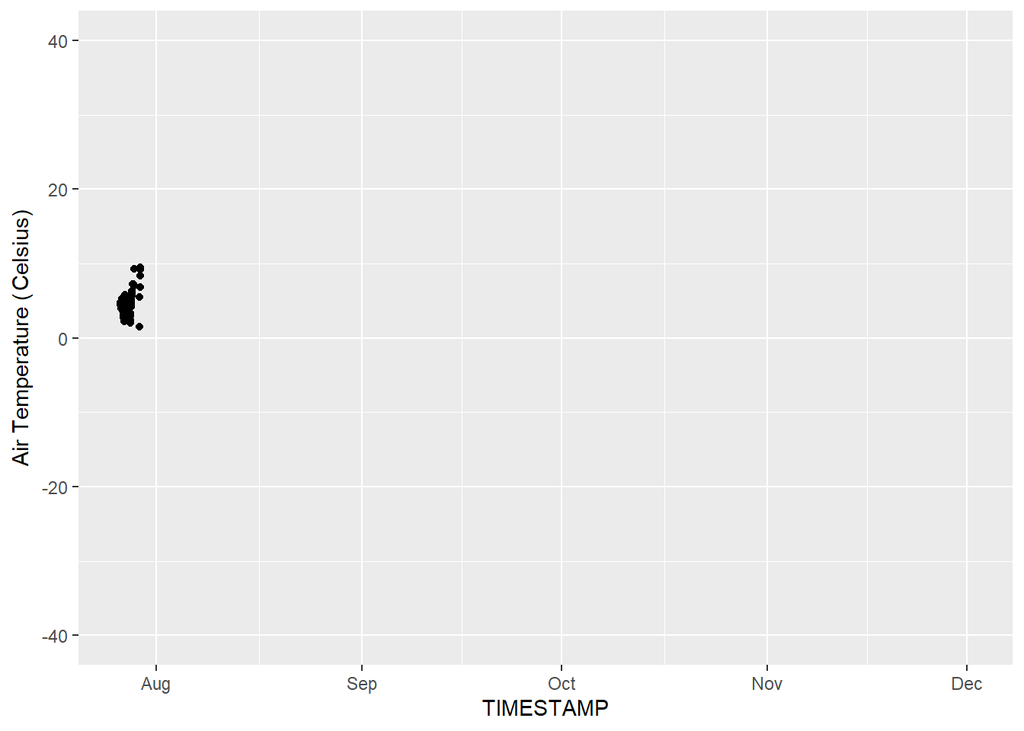

```r
#First we need to just convert from Kelvin to degrees C
df$TA_2_1_1_1_1 = ifelse(df$TA_2_1_1_1_1 > 200,df$TA_2_1_1_1_1 - 273.15,df$TA_2_1_1_1_1)

ggplot(data = df)+
  geom_point(aes(TIMESTAMP,TA_2_1_1_1_1),col='black')+
  scale_y_continuous(limits = c(-40,40),
                      expression('Air Temperature ('*Celsius*')'))
```

## Limits

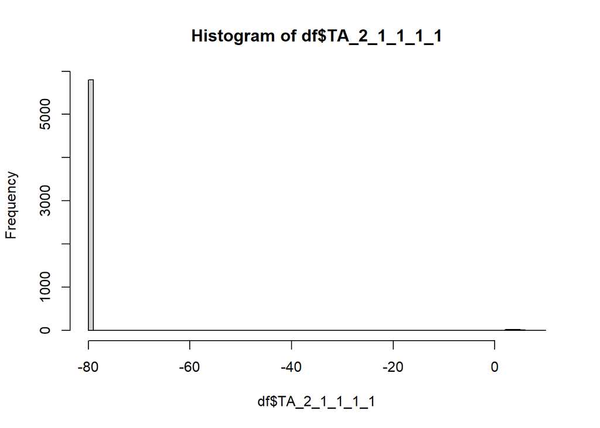

```r
hist(df$TA_2_1_1_1_1,breaks=100)
```

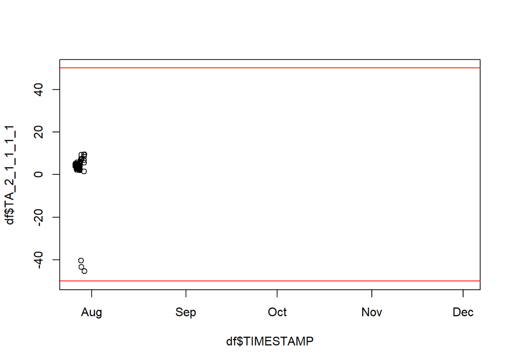

```r
plot(df$TIMESTAMP,df$TA_2_1_1_1_1,ylim = c(-50,50));abline(h=-50, col= 'red');abline(h=50, col='red')
```

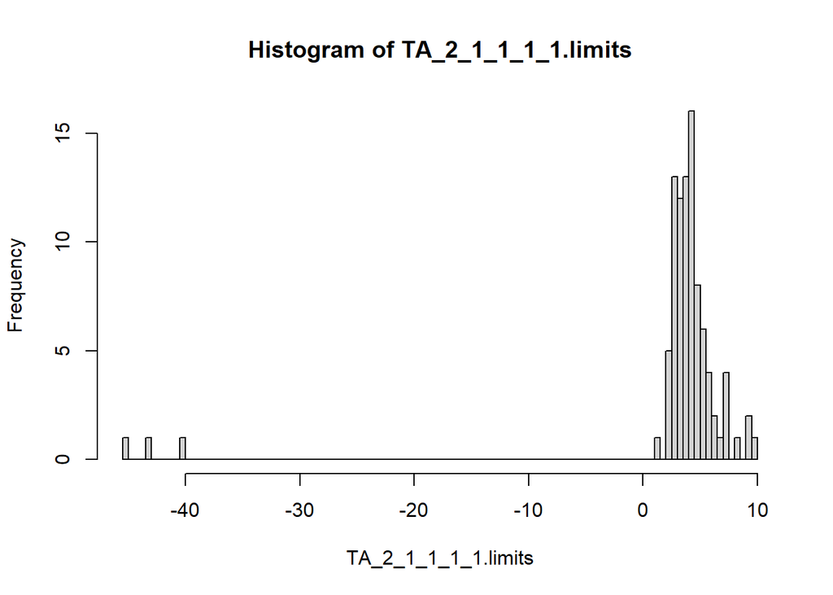

```r
TA_2_1_1_1_1.limits = replace(df$TA_2_1_1_1_1, df$TA_2_1_1_1_1 < -50 | df$TA_2_1_1_1_1 > 50,NA)
hist(TA_2_1_1_1_1.limits,breaks=100)
```

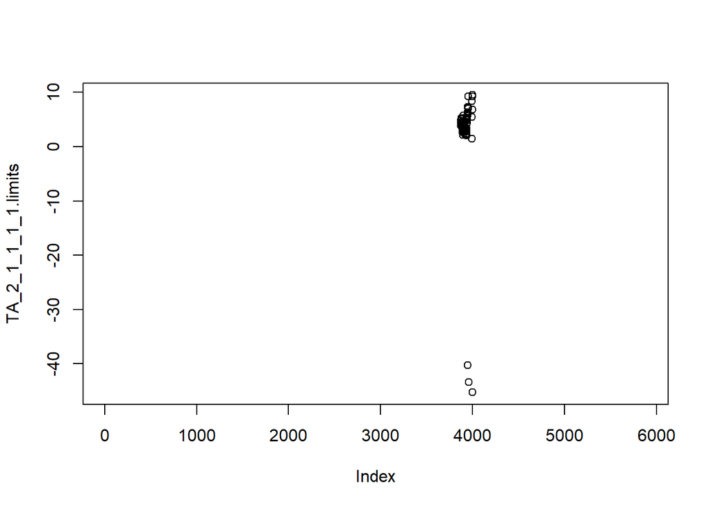

```r
plot(TA_2_1_1_1_1.limits)
```

#Relative Humidity

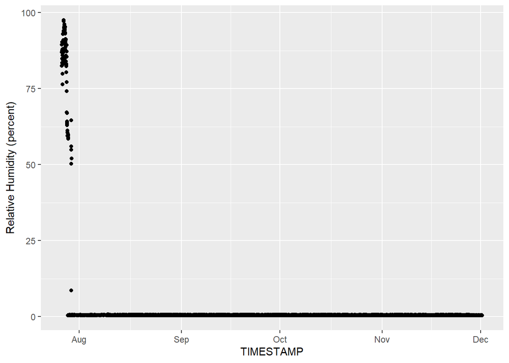

```r
ggplot(data = df)+
  geom_point(aes(TIMESTAMP,RH_19_3_1_1_1),col='black')+
  scale_y_continuous(#limits = c(20,100),
                     expression('Relative Humidity ('*percent*')'))
```

```r
 scale_x_datetime(limits = as.POSIXct(biomet_dates))
```

```
## <ScaleContinuousDatetime>
##  Range:
##  Limits: 1.72e+09 -- 1.73e+09
```

## Limits

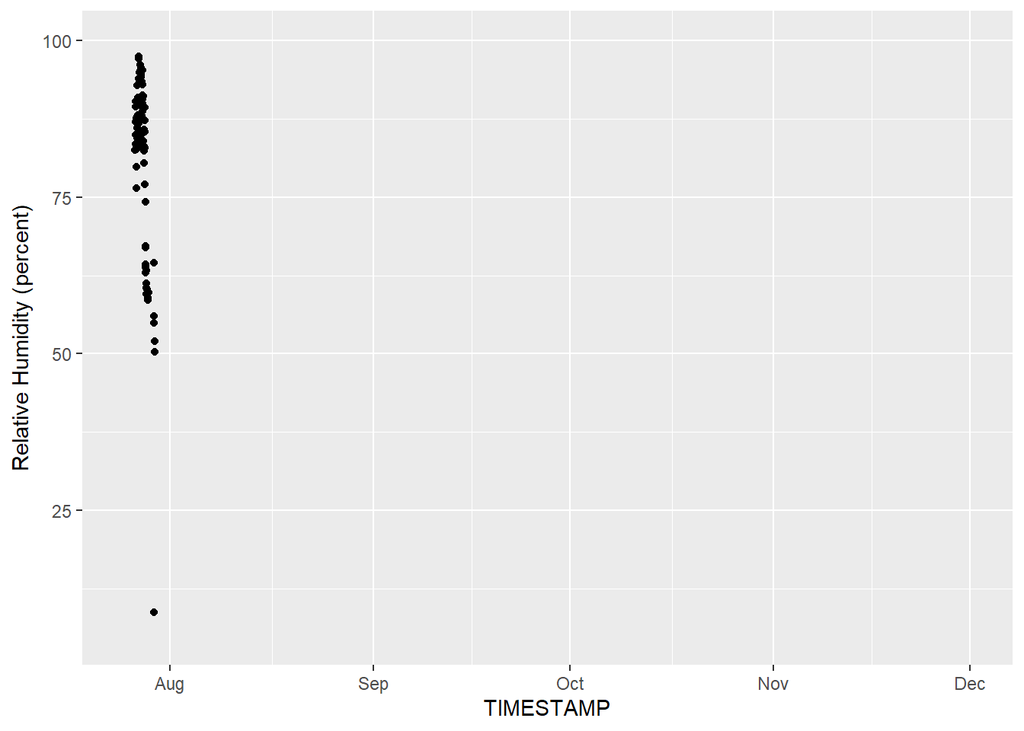

```r
RH_19_3_1_1_1.limits = df$RH_19_3_1_1_1

RH_19_3_1_1_1.limits = ifelse(df$RH_19_3_1_1_1 > 0 & df$TIMESTAMP <= '2022-9-23',NA, RH_19_3_1_1_1.limits)

df$RH_19_3_1_1_1.c = RH_19_3_1_1_1.limits

ggplot(data = df)+
  geom_point(aes(TIMESTAMP,RH_19_3_1_1_1.c),col='black')+
  scale_y_continuous(limits = c(5,100),
                     expression('Relative Humidity ('*percent*')'))+
  scale_x_datetime(limits = as.POSIXct(biomet_dates))
```

# Barometric Pressure

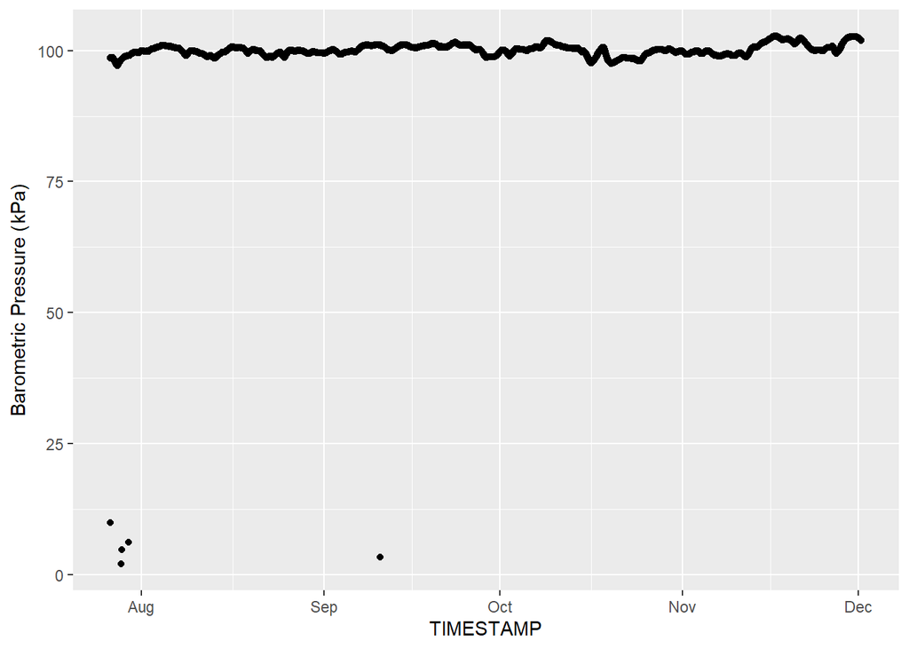

```r
ggplot(data = df)+
  geom_point(aes(TIMESTAMP,PA_4_2_1_1_1),col='black')+
  scale_y_continuous(#limits = c(90000,110000),
                     expression ('Barometric Pressure ('*kPa*')'))
```

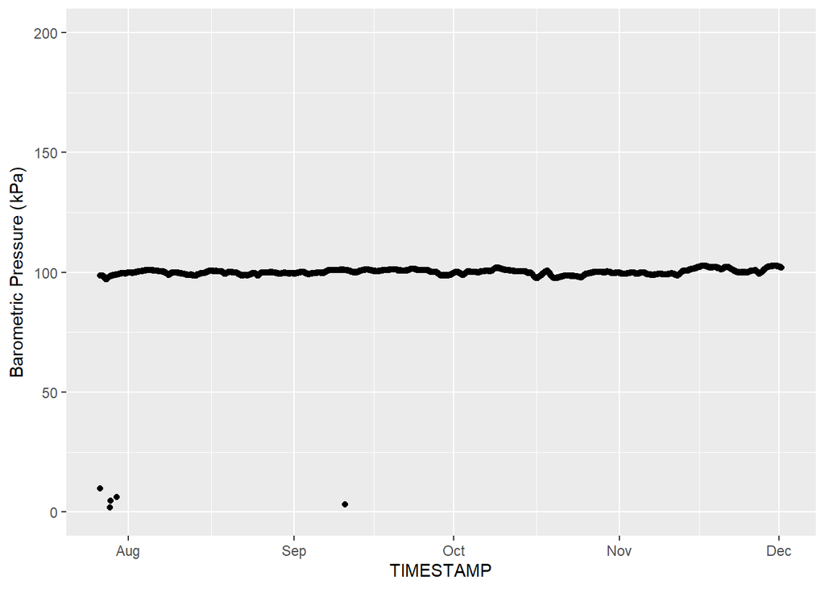

```r
#  scale_x_datetime(limits = as.POSIXct(biomet_dates))

df$PA_4_2_1_1_1 = ifelse(df$PA_4_2_1_1_1 > 97000,df$PA_4_2_1_1_1/1000,df$PA_4_2_1_1_1)

ggplot(data = df)+
  geom_point(aes(TIMESTAMP,PA_4_2_1_1_1),col='black')+
  scale_y_continuous(limits = c(0,200),
                     expression ('Barometric Pressure ('*kPa*')'))
```

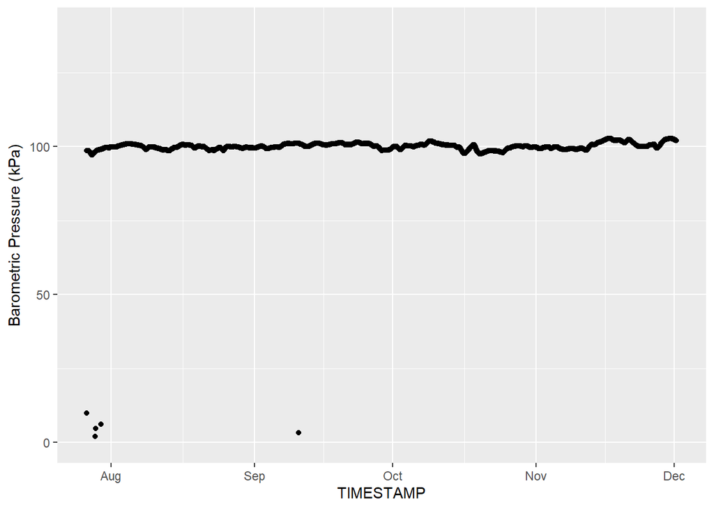

```r
df$PA_4_2_1_1_1 = ifelse(df$PA_4_2_1_1_1 > 150,df$PA_4_2_1_1_1/10,df$PA_4_2_1_1_1)

ggplot(data = df)+
  geom_point(aes(TIMESTAMP,PA_4_2_1_1_1),col='black')+
  scale_y_continuous(limits = c(0,140),
                     expression ('Barometric Pressure ('*kPa*')'))
```

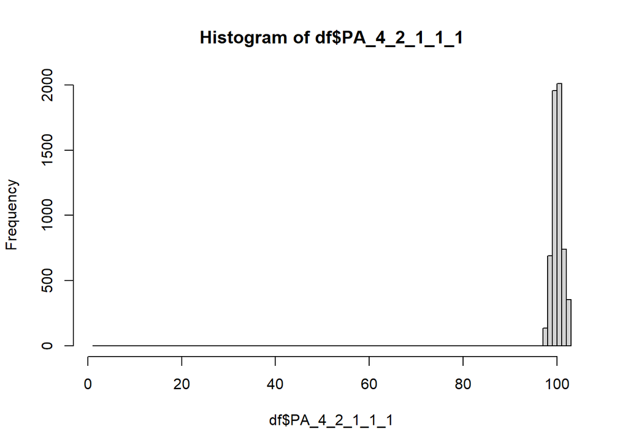

```r
hist(df$PA_4_2_1_1_1,breaks=100)
```

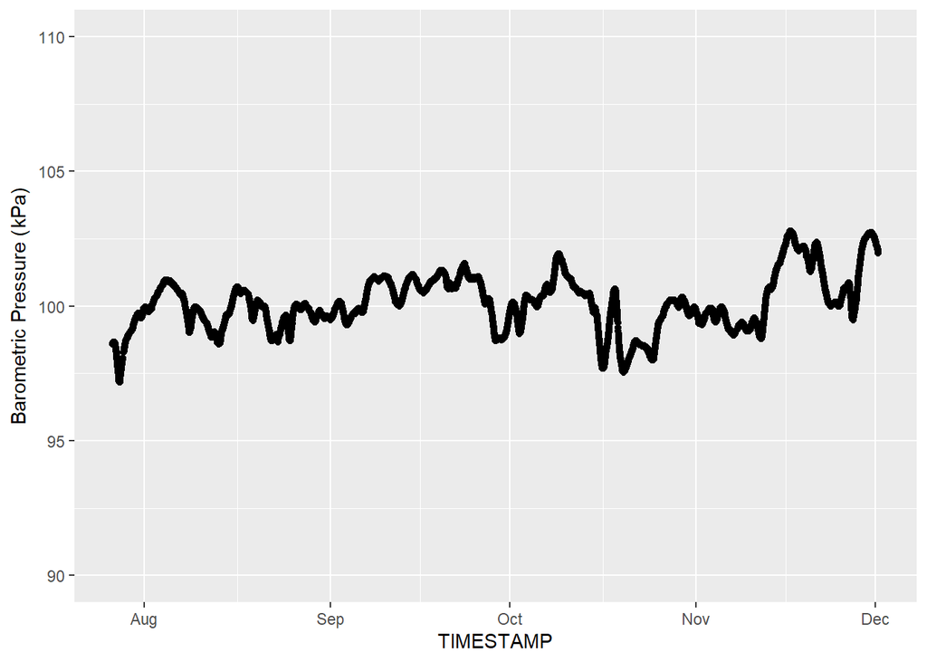

```r
ggplot(data = df)+
  geom_point(aes(TIMESTAMP,PA_4_2_1_1_1),col='black')+
  scale_y_continuous(limits = c(90,110),
                     expression ('Barometric Pressure ('*kPa*')'))
```

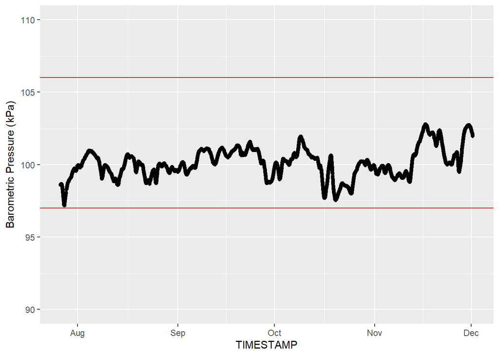

```r
PA_4_2_1_1_1.limits = ifelse(df$PA_4_2_1_1_1 > 110 | df$PA_4_2_1_1_1 < 97,NA, df$PA_4_2_1_1_1)

ggplot(data = df)+
  geom_point(aes(TIMESTAMP,PA_4_2_1_1_1.limits),col='black')+
  geom_hline(yintercept = 106,col = 'red')+
  geom_hline(yintercept = 97,col = 'red')+
  scale_y_continuous(limits = c(90,110),
                     expression ('Barometric Pressure ('*kPa*')'))
```

## Rolling MAD

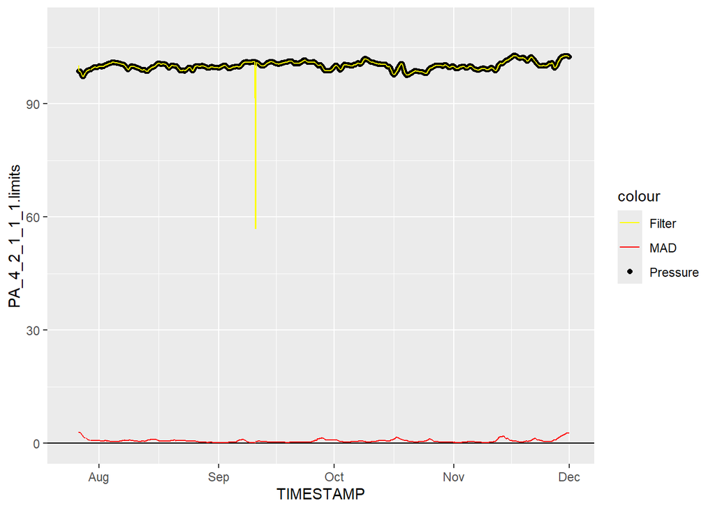

```r
f = PA_4_2_1_1_1.limits # first make a new flux vector to apply the above filters
# prepare the inputs for a zero-phase (forward and reverse) filter
ind       = which(complete.cases(f))   # first save the index of all the NAs
b         = rep(1,8)/8                 # moving average coefficient
a         = 1                          # coefficient of the ARMA filter
mad_i    = filtfilt(b, a, na.omit(f)) #create a forward and reverse ARMA filter
mad_filt = f                          # make a copy of the full fluxes again
mad_filt[ind] = mad_i                # apply the filter where the real data exist

n = 7*48 # set the length of the rolling filter, 48 half hours in day * x days
roll.mad = rollapply(data = mad_filt,
                     width = n,
                     FUN = mad,
                     partial = TRUE,
                     na.rm = T,
                     fill = NA)  #create a rolling MAD or sd or other
roll.mad[is.na(mad_filt)] = NA  #make NA values where NAs exist in the real data


ggplot(df)+geom_hline(yintercept = 0)+
  geom_point(aes(TIMESTAMP,PA_4_2_1_1_1.limits,col='Pressure'))+
  geom_line(aes(TIMESTAMP,mad_filt,col='Filter'))+
  geom_line(aes(TIMESTAMP,roll.mad,col='MAD'))+
  scale_y_continuous(limits = c(0,110))+
  scale_x_datetime(limits = as.POSIXct(biomet_dates,format="%F"))+
  scale_color_manual(values=c('yellow','red','black'))
```

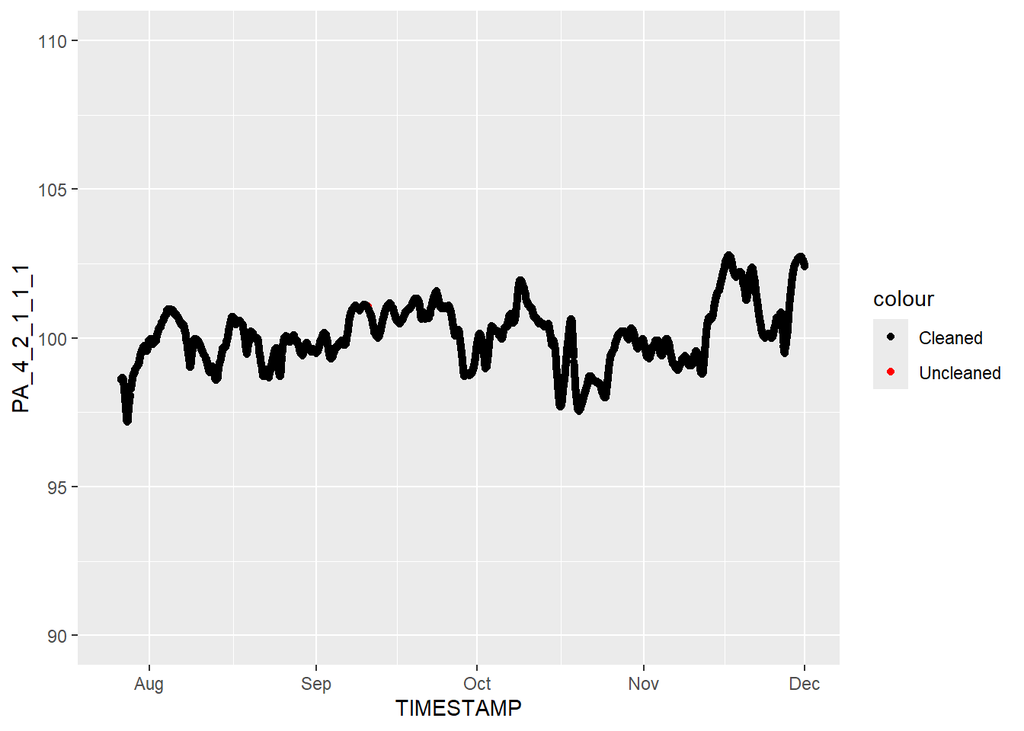

```r
#adjust this value (N) to tweak how many MADs to be away from the norm
N = 3

#Add clean value to dataframe (_.c)

df$PA_4_2_1_1_1.c = ifelse(abs(PA_4_2_1_1_1.limits - mad_filt) > (N * roll.mad),NA,PA_4_2_1_1_1.limits)

#Compare cleaned vs. uncleaned

ggplot(df)+geom_hline(yintercept = 0)+
  geom_point(aes(TIMESTAMP,PA_4_2_1_1_1,col='Uncleaned'))+
  geom_point(aes(TIMESTAMP,PA_4_2_1_1_1.c,col='Cleaned'))+
  scale_y_continuous(limits = c(90,110))+
  scale_x_datetime(limits = as.POSIXct(biomet_dates,format="%F"))+
  scale_color_manual(values=c('black','red'))
```

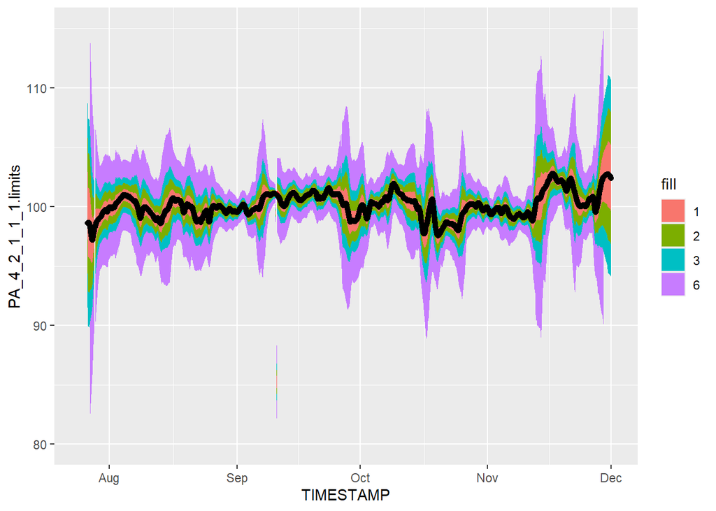

```r
ggplot(data = df)+
  geom_ribbon(aes(x = TIMESTAMP,ymax = mad_filt+roll.mad*6,ymin = mad_filt-roll.mad*6,fill='6'))+
  geom_ribbon(aes(x = TIMESTAMP,ymax = mad_filt+roll.mad*3,ymin = mad_filt-roll.mad*3,fill='3'))+
  geom_ribbon(aes(x = TIMESTAMP,ymax = mad_filt+roll.mad*2,ymin = mad_filt-roll.mad*2,fill='2'))+
  geom_ribbon(aes(x = TIMESTAMP,ymax = mad_filt+roll.mad*1,ymin = mad_filt-roll.mad*1,fill='1'))+
  geom_point(aes(TIMESTAMP,PA_4_2_1_1_1.limits),col='red')+
  geom_point(aes(TIMESTAMP,PA_4_2_1_1_1.c),col='black')+
  scale_y_continuous(limits = c(80,115))+
scale_x_datetime(limits = as.POSIXct(biomet_dates,format="%F"))
```

#Soil Heat Flux

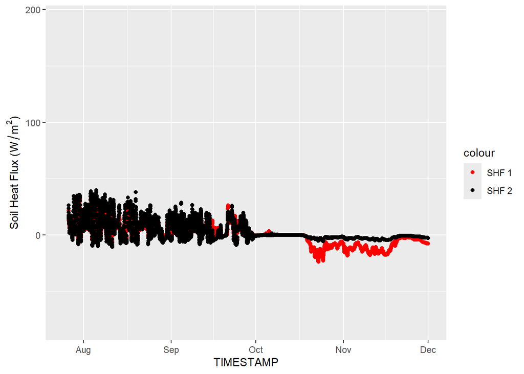

```r
ggplot(data = df)+
  geom_point(aes(TIMESTAMP,SHF_6_37_1_1_1,col='SHF 1'))+
  geom_point(aes(TIMESTAMP,SHF_6_37_2_1_1,col='SHF 2'))+
  scale_y_continuous(limits = c(-80,190),
                     expression ('Soil Heat Flux ('*W/m^2*')'))+
  scale_color_manual(values = c('red','black'))+
  scale_x_datetime(limits = as.POSIXct(biomet_dates))
```

## SHF1

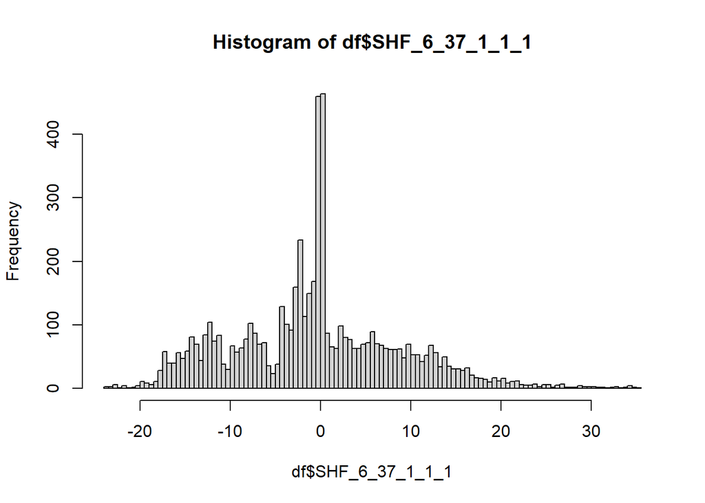

```r
hist(df$SHF_6_37_1_1_1,breaks=100)
```

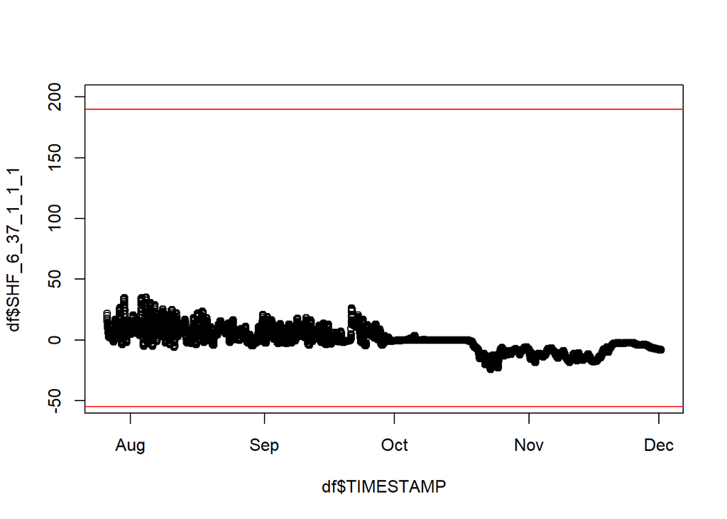

```r
plot(df$TIMESTAMP,df$SHF_6_37_1_1_1,ylim = c(-50,200));abline(h=-55, col= 'red');abline(h=190, col='red')
```

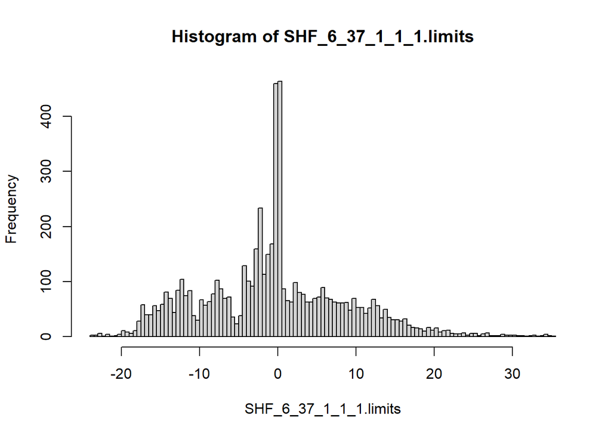

```r
SHF_6_37_1_1_1.limits = replace(df$SHF_6_37_1_1_1, df$SHF_6_37_1_1_1 < -55 | df$SHF_6_37_1_1_1 > 190,NA)
hist(SHF_6_37_1_1_1.limits,breaks=100)
```

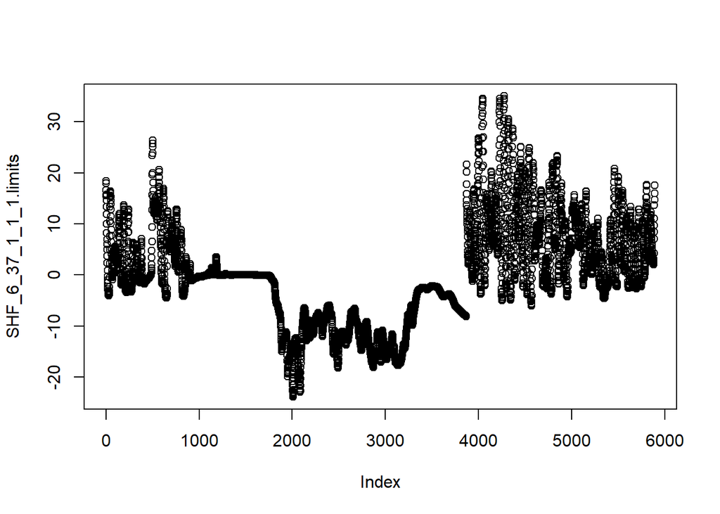

```r
plot(SHF_6_37_1_1_1.limits)
```

```r
df$SHF_6_37_1_1_1.c = SHF_6_37_1_1_1.limits
```

## SHF2

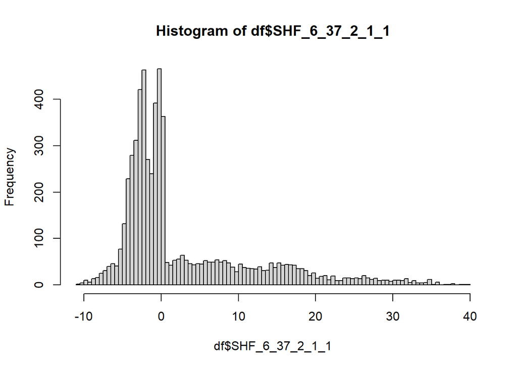

```r
hist(df$SHF_6_37_2_1_1,breaks=100)
```

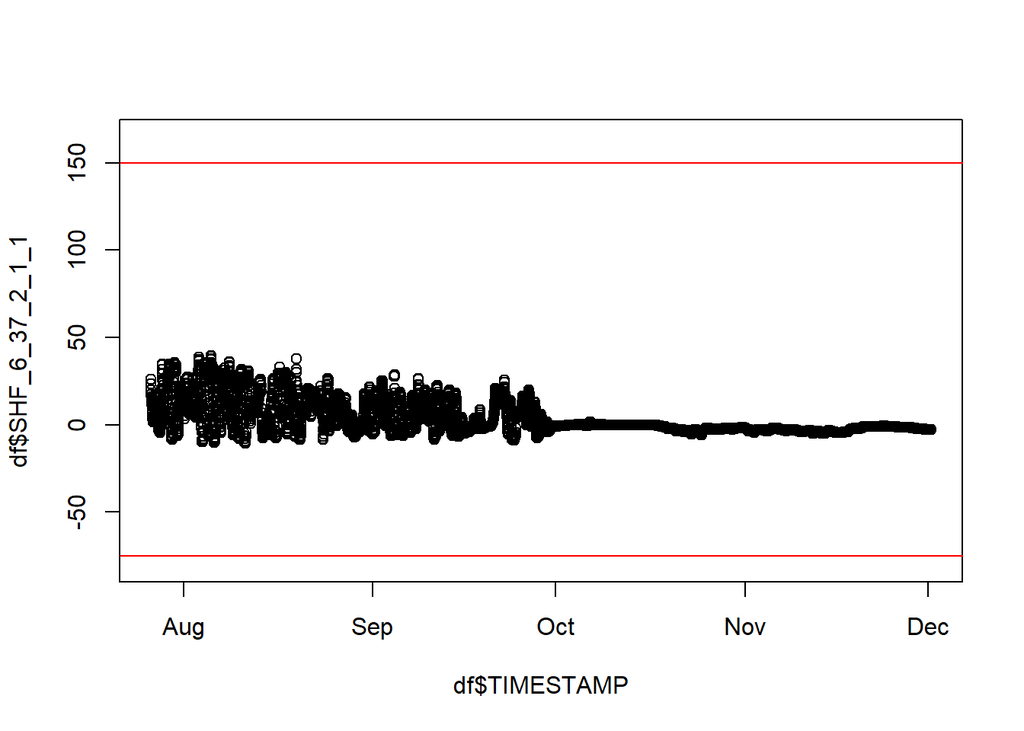

```r
plot(df$TIMESTAMP,df$SHF_6_37_2_1_1,ylim = c(-80,165));abline(h=-75, col= 'red');abline(h=150, col='red')
```

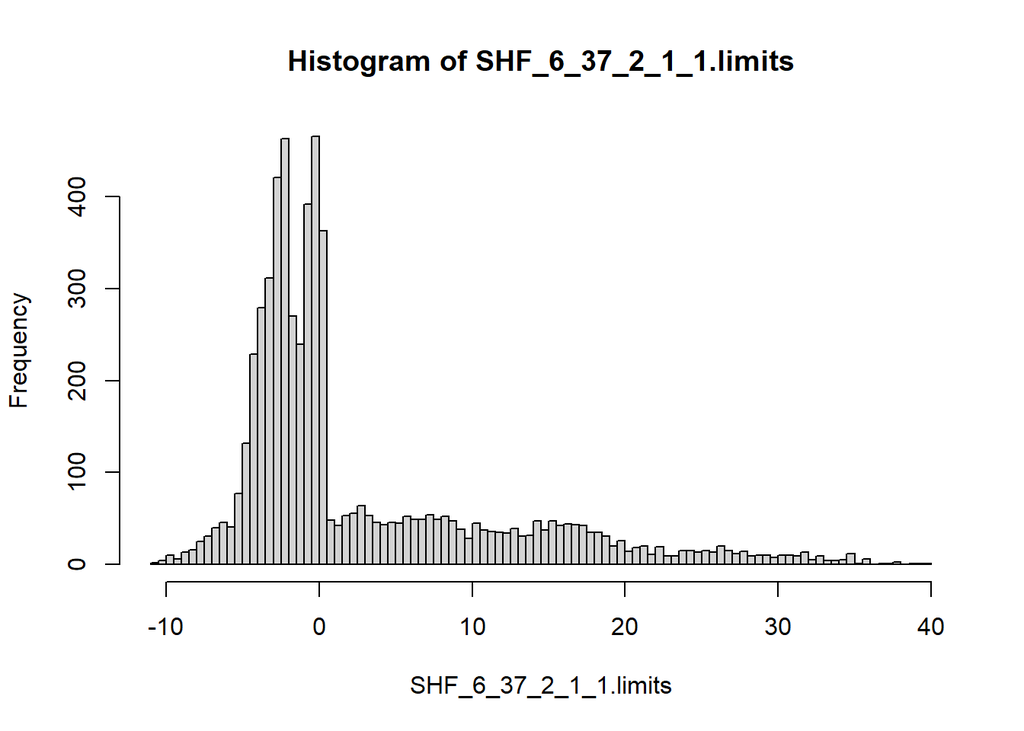

```r
SHF_6_37_2_1_1.limits = replace(df$SHF_6_37_2_1_1, df$SHF_6_37_2_1_1 < -75 | df$SHF_6_37_2_1_1 > 150,NA)
hist(SHF_6_37_2_1_1.limits,breaks=100)
```

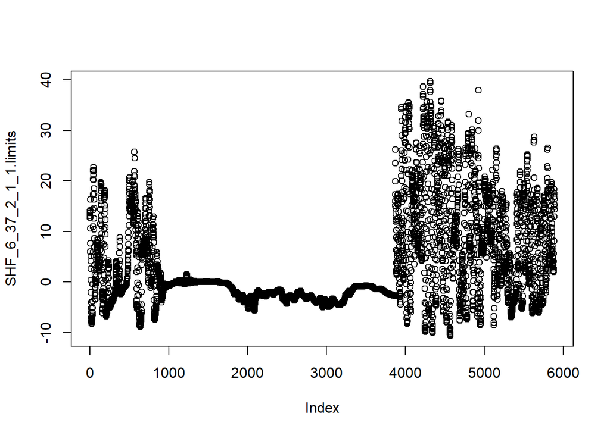

```r
plot(SHF_6_37_2_1_1.limits)
```

```r
df$SHF_6_37_2_1_1.c = SHF_6_37_2_1_1.limits
```

# Snow Depth

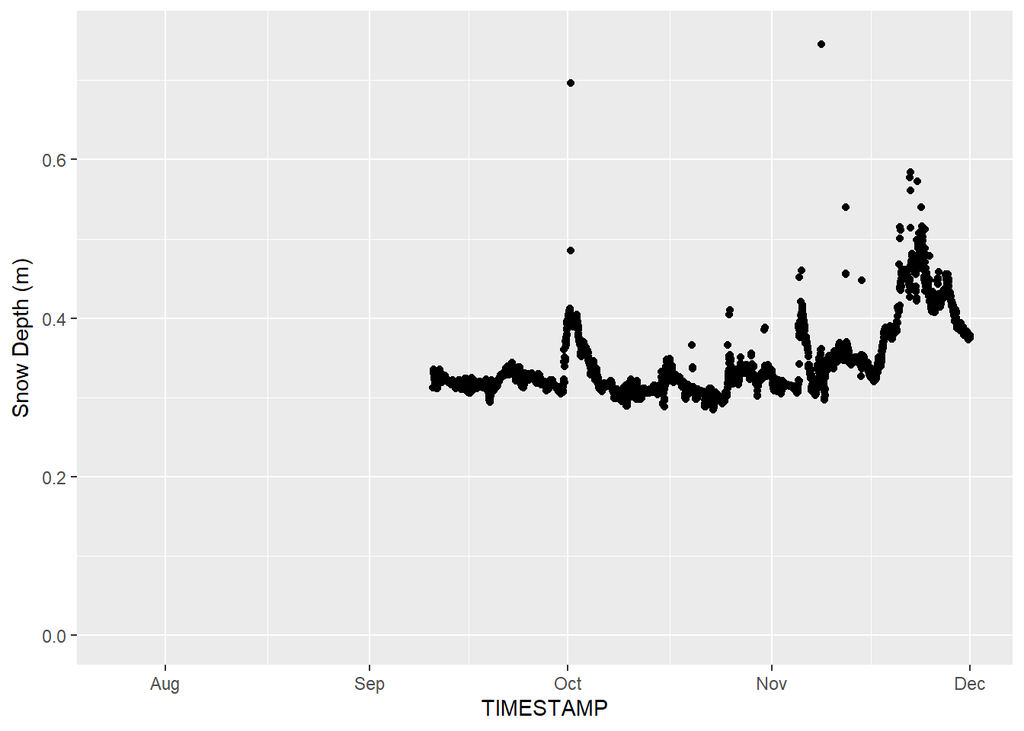

```r
ggplot(data = df)+
  geom_point(aes(TIMESTAMP,SD_10_99_1_1_1),col='black')+
  scale_y_continuous(limits = c(0,.75),
                     expression('Snow Depth ('*m*')'))+
  scale_x_datetime(limits = as.POSIXct(biomet_dates))
```

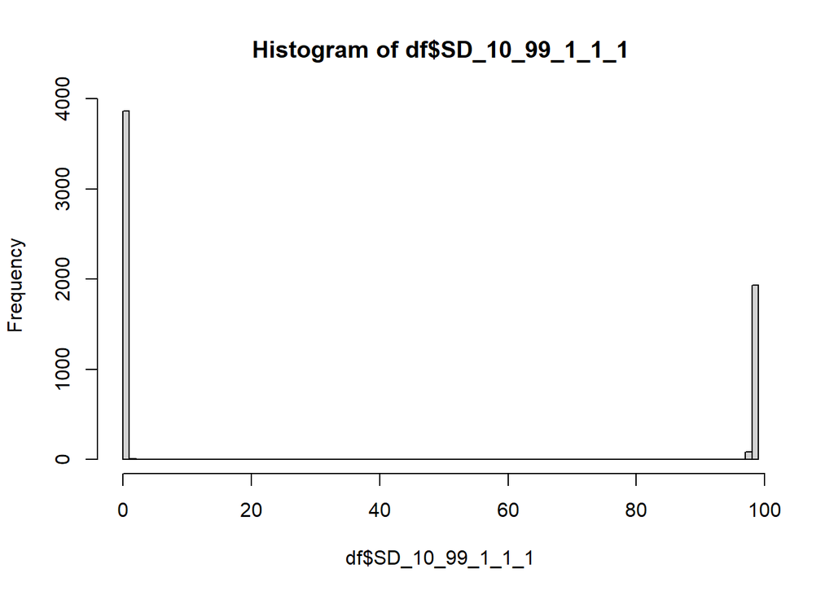

```r
hist(df$SD_10_99_1_1_1,breaks=100)
```

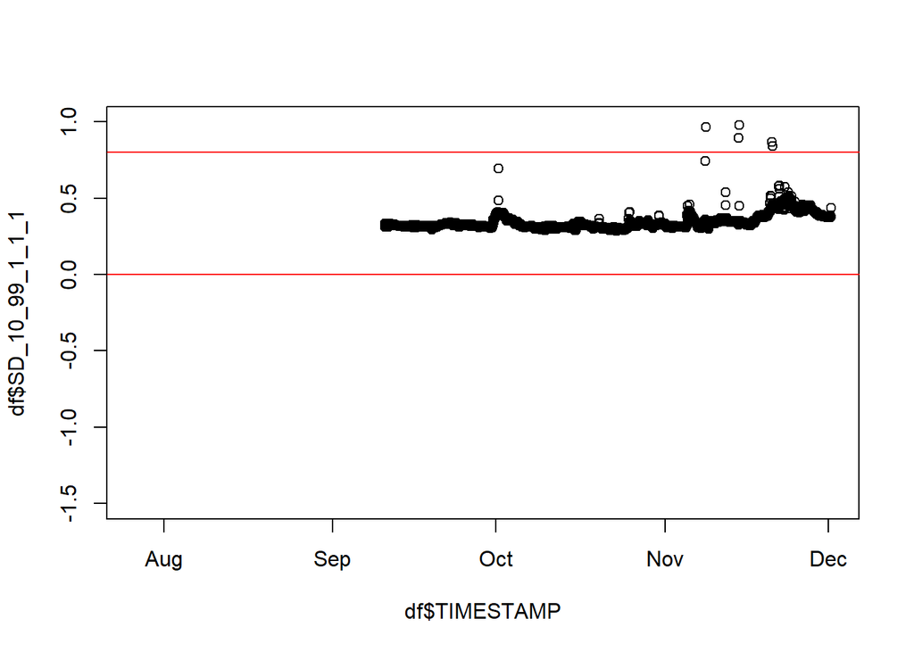

```r
plot(df$TIMESTAMP,df$SD_10_99_1_1_1,ylim = c(-1.5,1));abline(h=0, col= 'red');abline(h=.8, col='red')
```

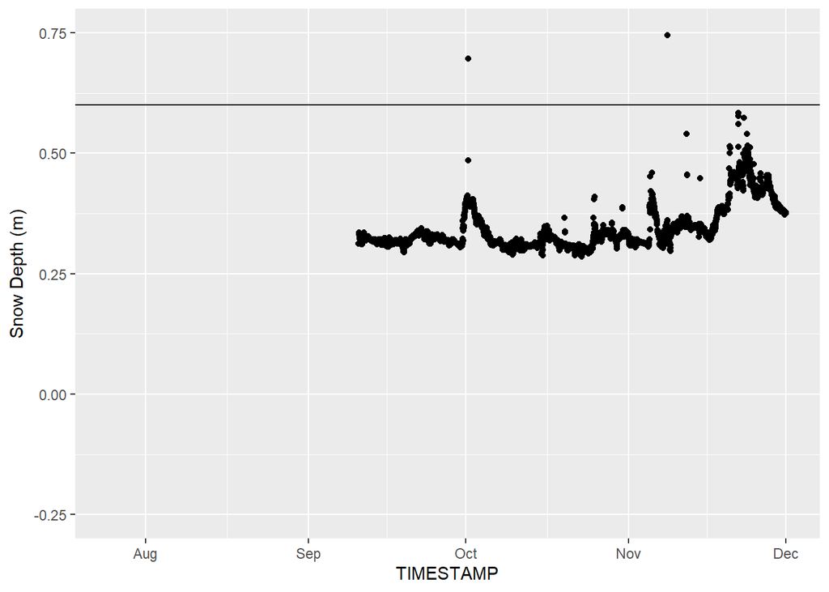

```r
SD_10_99_1_1_1.limits=df$SD_10_99_1_1_1

ggplot(data = df)+
  geom_point(aes(TIMESTAMP,SD_10_99_1_1_1.limits),col='black')+
  scale_y_continuous(limits = c(-.25,.75),
                     expression('Snow Depth ('*m*')'))+
  geom_hline(yintercept = .60)+
  scale_x_datetime(limits = as.POSIXct(biomet_dates))
```

```r
SD_10_99_1_1_1.limits = ifelse(df$SD_10_99_1_1_1 > .60, NA , SD_10_99_1_1_1.limits)

df$SD_10_99_1_1_1.c = SD_10_99_1_1_1.limits
```